# Coursework_7WCM2036_id_21087677

## Coursework – Data Classification (60 marks)

**Submission Requirements:** You need to submit two files to the link “Assignment>>Coursework assignment>>Coursework submission link. The two files are:

1. The provided Jupyter Notebook file, completed in .ipynb format.
2. The provided Jupyter Notebook file, completed in .html format.

Use File -> download as... -> HTML/IPYNB in the Jupyter Notebook menu bar to save this notebook in html/ipynb format. The programming language you should use to complete this assessment is Python (in version 3 and above). You can use any Python library or package. All Python skills needed to do this assessment have been covered in the practical sessions –practical notes are available on Canvas.

**Feedback:** A score and the filled-in individual Rubric with a general comment.

### Task 1: Data pre-processing and data exploration (12 marks)

#### a) Load the dataset as a pandas data frame (2 marks), and explore the features (4 marks).

```python
import pandas as pd
```

```python
df = pd.read_csv('Statlog_dataset.csv')
```

```python
df.head()
```

|  | compactness | circularity | distance_circularity | radius_ratio | pr.axis_aspect_ratio | max.length_aspect_ratio | scatter_ratio | elongatedness | pr.axis_rectangularity | max.length_rectangularity | scaled_variance | scaled_variance.1 | scaled_radius_of_gyration | scaled_radius_of_gyration.1 | skewness_about | skewness_about.1 | skewness_about.2 | hollows_ratio | class |
| --- | --- | --- | --- | --- | --- | --- | --- | --- | --- | --- | --- | --- | --- | --- | --- | --- | --- | --- | --- |
| 0 | 95 | 48.0 | 83.0 | 178.0 | 72.0 | 10 | 162.0 | 42.0 | 20.0 | 159 | 176.0 | 379.0 | 184.0 | 70.0 | 6.0 | 16.0 | 187.0 | 197 | van |
| 1 | 91 | 41.0 | 84.0 | 141.0 | 57.0 | 9 | 149.0 | 45.0 | 19.0 | 143 | 170.0 | 330.0 | 158.0 | 72.0 | 9.0 | 14.0 | 189.0 | 199 | van |
| 2 | 104 | 50.0 | 106.0 | 209.0 | 66.0 | 10 | 207.0 | 32.0 | 23.0 | 158 | 223.0 | 635.0 | 220.0 | 73.0 | 14.0 | 9.0 | 188.0 | 196 | car |
| 3 | 93 | 41.0 | 82.0 | 159.0 | 63.0 | 9 | 144.0 | 46.0 | 19.0 | 143 | 160.0 | 309.0 | 127.0 | 63.0 | 6.0 | 10.0 | 199.0 | 207 | van |
| 4 | 85 | 44.0 | 70.0 | 205.0 | 103.0 | 52 | 149.0 | 45.0 | 19.0 | 144 | 241.0 | 325.0 | 188.0 | 127.0 | 9.0 | 11.0 | 180.0 | 183 | bus |

```python
df.describe()
```

|  | compactness | circularity | distance_circularity | radius_ratio | pr.axis_aspect_ratio | max.length_aspect_ratio | scatter_ratio | elongatedness | pr.axis_rectangularity | max.length_rectangularity | scaled_variance | scaled_variance.1 | scaled_radius_of_gyration | scaled_radius_of_gyration.1 | skewness_about | skewness_about.1 | skewness_about.2 | hollows_ratio |
| --- | --- | --- | --- | --- | --- | --- | --- | --- | --- | --- | --- | --- | --- | --- | --- | --- | --- | --- |
| count | 846.000000 | 841.000000 | 842.000000 | 840.000000 | 844.000000 | 846.000000 | 845.000000 | 845.000000 | 843.000000 | 846.000000 | 843.000000 | 844.000000 | 844.000000 | 842.000000 | 840.000000 | 845.000000 | 845.000000 | 846.000000 |
| mean | 93.678487 | 44.828775 | 82.110451 | 168.888095 | 61.678910 | 8.567376 | 168.901775 | 40.933728 | 20.582444 | 147.998818 | 188.631079 | 439.494076 | 174.709716 | 72.447743 | 6.364286 | 12.602367 | 188.919527 | 195.632388 |
| std | 8.234474 | 6.152172 | 15.778292 | 33.520198 | 7.891463 | 4.601217 | 33.214848 | 7.816186 | 2.592933 | 14.515652 | 31.411004 | 176.666903 | 32.584808 | 7.486190 | 4.920649 | 8.936081 | 6.155809 | 7.438797 |
| min | 73.000000 | 33.000000 | 40.000000 | 104.000000 | 47.000000 | 2.000000 | 112.000000 | 26.000000 | 17.000000 | 118.000000 | 130.000000 | 184.000000 | 109.000000 | 59.000000 | 0.000000 | 0.000000 | 176.000000 | 181.000000 |
| 25% | 87.000000 | 40.000000 | 70.000000 | 141.000000 | 57.000000 | 7.000000 | 147.000000 | 33.000000 | 19.000000 | 137.000000 | 167.000000 | 318.000000 | 149.000000 | 67.000000 | 2.000000 | 5.000000 | 184.000000 | 190.250000 |
| 50% | 93.000000 | 44.000000 | 80.000000 | 167.000000 | 61.000000 | 8.000000 | 157.000000 | 43.000000 | 20.000000 | 146.000000 | 179.000000 | 363.500000 | 173.500000 | 71.500000 | 6.000000 | 11.000000 | 188.000000 | 197.000000 |
| 75% | 100.000000 | 49.000000 | 98.000000 | 195.000000 | 65.000000 | 10.000000 | 198.000000 | 46.000000 | 23.000000 | 159.000000 | 217.000000 | 587.000000 | 198.000000 | 75.000000 | 9.000000 | 19.000000 | 193.000000 | 201.000000 |
| max | 119.000000 | 59.000000 | 112.000000 | 333.000000 | 138.000000 | 55.000000 | 265.000000 | 61.000000 | 29.000000 | 188.000000 | 320.000000 | 1018.000000 | 268.000000 | 135.000000 | 22.000000 | 41.000000 | 206.000000 | 211.000000 |

```python
df.info()
```

```
<class 'pandas.core.frame.DataFrame'>
RangeIndex: 846 entries, 0 to 845
Data columns (total 19 columns):
 #   Column                       Non-Null Count  Dtype
---  ------                       --------------  -----
 0   compactness                  846 non-null    int64
 1   circularity                  841 non-null    float64
 2   distance_circularity         842 non-null    float64
 3   radius_ratio                 840 non-null    float64
 4   pr.axis_aspect_ratio         844 non-null    float64
 5   max.length_aspect_ratio      846 non-null    int64
 6   scatter_ratio                845 non-null    float64
 7   elongatedness                845 non-null    float64
 8   pr.axis_rectangularity       843 non-null    float64
 9   max.length_rectangularity    846 non-null    int64
 10  scaled_variance              843 non-null    float64
 11  scaled_variance.1            844 non-null    float64
 12  scaled_radius_of_gyration    844 non-null    float64
 13  scaled_radius_of_gyration.1  842 non-null    float64
 14  skewness_about               840 non-null    float64
 15  skewness_about.1             845 non-null    float64
 16  skewness_about.2             845 non-null    float64
 17  hollows_ratio                846 non-null    int64
 18  class                        846 non-null    object
dtypes: float64(14), int64(4), object(1)
memory usage: 125.7+ KB
```

```python
df.shape
```

```
(846, 19)
```

#### b) Handle Missing values (if any)(2 marks).

```python
df.isnull().sum()
```

```
compactness                    0
circularity                    5
distance_circularity           4
radius_ratio                   6
pr.axis_aspect_ratio           2
max.length_aspect_ratio        0
scatter_ratio                  1
elongatedness                  1
pr.axis_rectangularity         3
max.length_rectangularity      0
scaled_variance                3
scaled_variance.1              2
scaled_radius_of_gyration      2
scaled_radius_of_gyration.1    4
skewness_about                 6
skewness_about.1               1
skewness_about.2               1
hollows_ratio                  0
class                          0
dtype: int64
```

```python
from sklearn.impute import SimpleImputer
```

```python
numeric_columns = df.select_dtypes(include=['float64', 'int64']).columns
```

```python
non_numeric_columns = df.select_dtypes(include=['object']).columns
```

```python
imputer = SimpleImputer(strategy='mean')
```

```python
numeric_imputed = imputer.fit_transform(df[numeric_columns])
```

```python
numeric_imputed_df = pd.DataFrame(numeric_imputed, columns=numeric_columns)
```

```python
df_final = pd.concat([numeric_imputed_df, df[non_numeric_columns]], axis=1)
```

```python
df_final.isnull().sum()
```

```
compactness                    0
circularity                    0
distance_circularity           0
radius_ratio                   0
pr.axis_aspect_ratio           0
max.length_aspect_ratio        0
scatter_ratio                  0
elongatedness                  0
pr.axis_rectangularity         0
max.length_rectangularity      0
scaled_variance                0
scaled_variance.1              0
scaled_radius_of_gyration      0
scaled_radius_of_gyration.1    0
skewness_about                 0
skewness_about.1               0
skewness_about.2               0
hollows_ratio                  0
class                          0
dtype: int64
```

```python
df_final.shape
```

```
(846, 19)
```

#### c) Divide the dataset into a training set (60%) , a validation set (20%) and a testing set (20%) (4 mark).

```python
from sklearn.model_selection import train_test_split
```

```python
X = df_final.drop(columns=['class'])
```

```python
y = df_final['class']
```

```python
X_train, X_temp, y_train, y_temp = train_test_split(X,y,test_size=0.4, random_state=421, shuffle=True)
```

```python
X_val, X_test, y_val, y_test = train_test_split(X_temp, y_temp, test_size=0.5, random_state=421, shuffle=True)
```

```python
len(X_train)
```

```
507
```

```python
len(X_val)
```

```
169
```

```python
len(X_test)
```

```
170
```

### Task 2: Do a principal component analysis (18 marks)

#### a) Standardise the training dataset and perform a PCA analysis on the training data set. Explain your findings in a markdown cell (6 marks).

```python
from sklearn.preprocessing import StandardScaler
```

```python
scaler = StandardScaler()
```

```python
X_train_scaled = scaler.fit_transform(X_train)
```

```python
X_test_scaled = scaler.transform(X_test)
```

```python
X_val_scaled = scaler.transform(X_val)
```

```python
X_train
```

|  | compactness | circularity | distance_circularity | radius_ratio | pr.axis_aspect_ratio | max.length_aspect_ratio | scatter_ratio | elongatedness | pr.axis_rectangularity | max.length_rectangularity | scaled_variance | scaled_variance.1 | scaled_radius_of_gyration | scaled_radius_of_gyration.1 | skewness_about | skewness_about.1 | skewness_about.2 | hollows_ratio |
| --- | --- | --- | --- | --- | --- | --- | --- | --- | --- | --- | --- | --- | --- | --- | --- | --- | --- | --- |
| 842 | 89.0 | 46.0 | 84.0 | 163.0 | 66.00000 | 11.0 | 159.0 | 43.0 | 20.0 | 159.0 | 173.0 | 368.0 | 176.0 | 72.0 | 1.0 | 20.0 | 186.0 | 197.0 |
| 462 | 97.0 | 47.0 | 81.0 | 183.0 | 64.00000 | 8.0 | 168.0 | 39.0 | 20.0 | 150.0 | 193.0 | 426.0 | 182.0 | 70.0 | 11.0 | 2.0 | 192.0 | 198.0 |
| 195 | 86.0 | 43.0 | 66.0 | 130.0 | 56.00000 | 7.0 | 152.0 | 44.0 | 19.0 | 142.0 | 177.0 | 340.0 | 173.0 | 81.0 | 6.0 | 14.0 | 181.0 | 185.0 |
| 440 | 101.0 | 51.0 | 98.0 | 194.0 | 60.00000 | 10.0 | 195.0 | 34.0 | 22.0 | 161.0 | 219.0 | 572.0 | 219.0 | 67.0 | 0.0 | 10.0 | 192.0 | 201.0 |
| 619 | 97.0 | 55.0 | 96.0 | 170.0 | 54.00000 | 10.0 | 216.0 | 31.0 | 24.0 | 173.0 | 219.0 | 685.0 | 218.0 | 75.0 | 0.0 | 4.0 | 184.0 | 193.0 |
| ... | ... | ... | ... | ... | ... | ... | ... | ... | ... | ... | ... | ... | ... | ... | ... | ... | ... | ... |
| 591 | 80.0 | 36.0 | 69.0 | 127.0 | 56.00000 | 7.0 | 128.0 | 53.0 | 18.0 | 124.0 | 147.0 | 240.0 | 133.0 | 70.0 | 2.0 | 21.0 | 183.0 | 191.0 |
| 19 | 101.0 | 56.0 | 100.0 | 215.0 | 61.67891 | 10.0 | 208.0 | 32.0 | 24.0 | 169.0 | 227.0 | 651.0 | 223.0 | 74.0 | 6.0 | 5.0 | 186.0 | 193.0 |
| 492 | 85.0 | 43.0 | 66.0 | 130.0 | 57.00000 | 6.0 | 151.0 | 45.0 | 19.0 | 143.0 | 173.0 | 333.0 | 168.0 | 86.0 | 4.0 | 9.0 | 180.0 | 183.0 |
| 565 | 101.0 | 48.0 | 85.0 | 191.0 | 60.00000 | 11.0 | 175.0 | 38.0 | 21.0 | 153.0 | 192.0 | 458.0 | 187.0 | 62.0 | 5.0 | 22.0 | 197.0 | 210.0 |
| 343 | 102.0 | 54.0 | 101.0 | 190.0 | 58.00000 | 10.0 | 222.0 | 30.0 | 25.0 | 171.0 | 224.0 | 728.0 | 203.0 | 71.0 | 13.0 | 6.0 | 189.0 | 198.0 |

507 rows × 18 columns

```python
X_train_scaled = pd.DataFrame(X_train_scaled, columns=X_train.columns)
```

```python
X_train_scaled.head()
```

|  | compactness | circularity | distance_circularity | radius_ratio | pr.axis_aspect_ratio | max.length_aspect_ratio | scatter_ratio | elongatedness | pr.axis_rectangularity | max.length_rectangularity | scaled_variance | scaled_variance.1 | scaled_radius_of_gyration | scaled_radius_of_gyration.1 | skewness_about | skewness_about.1 | skewness_about.2 | hollows_ratio |
| --- | --- | --- | --- | --- | --- | --- | --- | --- | --- | --- | --- | --- | --- | --- | --- | --- | --- | --- |
| 0 | -0.591559 | 0.139922 | 0.106049 | -0.183690 | 0.605474 | 0.549436 | -0.331147 | 0.296061 | -0.268354 | 0.696462 | -0.518794 | -0.435069 | -0.019726 | -0.100471 | -1.066846 | 0.840015 | -0.436089 | 0.226273 |
| 1 | 0.384586 | 0.300171 | -0.080665 | 0.415137 | 0.333771 | -0.098890 | -0.069271 | -0.208063 | -0.268354 | 0.087658 | 0.095121 | -0.120253 | 0.159175 | -0.371497 | 0.958616 | -1.207852 | 0.532277 | 0.359052 |
| 2 | -0.957614 | -0.340828 | -1.014233 | -1.171755 | -0.753039 | -0.314999 | -0.534828 | 0.422093 | -0.642562 | -0.453501 | -0.396011 | -0.587049 | -0.109177 | 1.119146 | -0.054115 | 0.157393 | -1.243060 | -1.367068 |
| 3 | 0.872658 | 0.941171 | 0.977379 | 0.744492 | -0.209634 | 0.333327 | 0.716357 | -0.838219 | 0.480062 | 0.831752 | 0.893210 | 0.672214 | 1.262398 | -0.778036 | -1.269392 | -0.297689 | 0.532277 | 0.757387 |
| 4 | 0.384586 | 1.582171 | 0.852903 | 0.025900 | -1.024742 | 0.333327 | 1.327401 | -1.216313 | 1.228479 | 1.643490 | 0.893210 | 1.285561 | 1.232581 | 0.306068 | -1.269392 | -0.980311 | -0.758878 | -0.304840 |

```python
from sklearn.decomposition import PCA
```

```python
pca = PCA(0.95)
```

```python
X_train_pca = pca.fit_transform(X_train_scaled)
```

```python
X_train_pca
```

```
array([[-4.13422176e-01,  2.11325268e-03,  9.05214202e-01, ...,
         7.95397897e-03,  1.33272144e+00, -7.32079128e-01],
       [ 3.20673270e-01,  7.17198535e-01,  6.71456973e-02, ...,
        -4.13805656e-01, -4.37504741e-01,  1.12441160e-02],
       [-2.17066965e+00, -2.26107822e+00, -1.84921085e-01, ...,
         4.70027209e-01, -3.25995340e-02, -1.70185479e-01],
       ...,
       [-2.41809224e+00, -2.87428203e+00,  1.00144401e-01, ...,
        -1.20123235e-01, -2.32428721e-01, -8.04517037e-02],
       [ 1.25980472e+00,  2.64396634e+00, -3.73994029e-01, ...,
         2.40569316e-01,  1.06060489e+00,  2.54173521e-02],
       [ 4.08556973e+00, -2.33877542e-01, -8.37226879e-01, ...,
         1.64620849e-01,  1.43883081e-01,  5.23267975e-01]])
```

```python
explained_variance_ratio = pca.explained_variance_ratio_
```

```python
explained_variance_ratio
```

```
array([0.52544505, 0.17283392, 0.09792973, 0.06479741, 0.05028479,
       0.03149046, 0.02030275])
```

```python
cumulative_variance = explained_variance_ratio.cumsum()
```

```python
cumulative_variance
```

```
array([0.52544505, 0.69827897, 0.7962087 , 0.86100611, 0.91129089,
       0.94278136, 0.96308411])
```

The training dataset was standardized to ensure all features have a mean of 0 and a standard deviation of 1. We can compare the result by looking at X_train and X_train_scaled.

Principal Component Analysis was applied to the standardized training dataset to reduce its diminensionality while retaining as much variance as possible.

The explained_variance_ratio shows that the first principal component (PC1) captures more than half of the total variance at 52.54%. Followed by the other components: PC2: 17.28% PC3: 9.79% PC4: 6.4% PC5: 5.03% PC6: 3.15% PC7: 2.03%

The cumulative_variance shows the total variance retained by adding each principal component. The first 6 components captures almost 95% of the total variance.

#### b) Plot a scree plot to report variances captured by each principal component. Explain your findings in a markdown cell (4 marks).

```python
import matplotlib.pyplot as plt
```

```python
import numpy as np
```

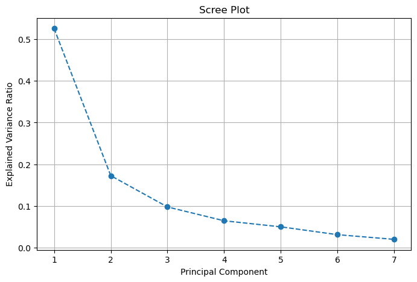

```python
# Create a scree plot for explained variance ratio
plt.figure(figsize=(8, 5))
plt.plot(range(1, len(explained_variance_ratio) + 1), explained_variance_ratio, marker='o', linestyle='--')
plt.title('Scree Plot')
plt.xlabel('Principal Component')
plt.ylabel('Explained Variance Ratio')
plt.xticks(range(1, len(explained_variance_ratio) + 1))
plt.grid()
plt.show()
```

The result clearly shows that PC1 captures the most variance in the dataset, while subsequent components show progressively lesser variance. This suggest that it may be optimal to retain just the first 3 components which explain 79.62% of the variance, capturing the majority of the dataset while reducing its dimensionality.

#### c) Project the test set on the same PCA space produced by the training dataset (2 marks).

```python
X_test_scaled = pd.DataFrame(X_test_scaled, columns=X_test.columns)
```

```python
X_test_pca = pca.transform(X_test_scaled)
```

```python
X_test_pca
```

```
array([[ 4.75529720e+00,  1.21874017e+00, -3.99338429e-01, ...,
         3.84394943e+00, -2.97634379e-01, -4.13876481e-01],
       [-2.20463500e+00,  2.60261724e+00, -7.08907451e-01, ...,
         9.76215477e-01,  4.19001988e-01, -1.35405273e-01],
       [ 1.74792715e+00, -5.09928961e-01, -4.74893210e-01, ...,
        -1.01492075e+00, -1.06018283e+00,  5.31651052e-01],
       ...,
       [-1.79750200e+00,  1.62666403e+00,  2.29724571e-01, ...,
        -2.09143614e-01, -5.58929794e-01,  1.44858656e-01],
       [-1.79131454e+00,  3.07591522e+00,  1.58215898e-01, ...,
        -8.72091148e-02, -1.72668283e+00,  4.79887482e-01],
       [-2.18560522e+00,  1.64882453e+00,  2.51965960e-01, ...,
        -8.50932793e-04, -4.05876775e-01, -5.05084731e-01]])
```

#### d) Plot two subplots in one figure: one for the training data in the PC1 and PC2 projection space and label the data in the picture according to its class; the other one for the test data in the same PCA space and label the data in the picture according to its class. Explain your findings in a markdown cell (6 marks)

```python
mapping_df = pd.DataFrame({
    'Original': df['class'].astype('category').cat.categories,
})
mapping_df
```

|  | Original |
| --- | --- |
| 0 | bus |
| 1 | car |
| 2 | van |

```python
labels_class = list(mapping_df['Original'])
labels_class
```

```
['bus', 'car', 'van']
```

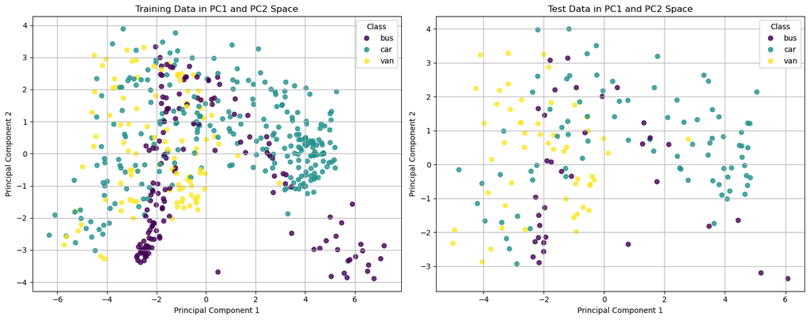

```python
X_train_pc1_pc2 = X_train_pca[:, :2]
X_test_pc1_pc2 = X_test_pca[:, :2]

# Plot the training and test data in PC1 and PC2 space
fig, axes = plt.subplots(1, 2, figsize=(15, 6))

# Training Data Plot
scatter_train = axes[0].scatter(X_train_pc1_pc2[:, 0], X_train_pc1_pc2[:, 1], c=y_train.astype('category').cat.codes, cmap='viridis', alpha=0.8)
axes[0].set_title('Training Data in PC1 and PC2 Space')
axes[0].set_xlabel('Principal Component 1')
axes[0].set_ylabel('Principal Component 2')
axes[0].grid(True)

handles_train, _ = scatter_train.legend_elements()
legend1 = axes[0].legend(handles_train, labels_class, title="Class")
axes[0].add_artist(legend1)

# Test Data Plot
scatter_test = axes[1].scatter(X_test_pc1_pc2[:, 0], X_test_pc1_pc2[:, 1], c=y_test.astype('category').cat.codes, cmap='viridis', alpha=0.8)
axes[1].set_title('Test Data in PC1 and PC2 Space')
axes[1].set_xlabel('Principal Component 1')
axes[1].set_ylabel('Principal Component 2')
axes[1].grid(True)


handles_test, _ = scatter_test.legend_elements()
legend2 = axes[1].legend(handles_test, labels_class, title="Class")
axes[1].add_artist(legend2)

plt.tight_layout()
plt.show()
```

Firstly, the two plots indicate the similarity in the distribution of components, suggesting that the PCA transformation was applied consistently. The training data shows a higher density in the plots, as it comprises a larger dataset compared to the test data.

There is a noticeable separation between the classes: Vans appear predominantly on the left side, Cars form a distinct cluster on the right, and Buses occupy the middle and far-right regions, showing significant separation from the other classes.

However, overlapping regions between the classes, particularly in the middle section, indicate areas of potential misclassification. These overlaps may negatively impact the overall model performance, as they suggest that the model might struggle to clearly distinguish between some classes in these regions.

### Task 3: Do a classification using the Naïve Bayes Classification model. Explain your findings in a markdown cell (12 marks)

Train the model using the training set and report the performance on the validation set and test set including accuracy rate.

```python
from sklearn.naive_bayes import GaussianNB
```

```python
from sklearn.metrics import accuracy_score, classification_report, confusion_matrix
```

```python
nb_model = GaussianNB()
```

```python
nb_model.fit(X_train_pca, y_train)
```

```
GaussianNB()
```

```python
X_val_scaled = pd.DataFrame(X_val_scaled, columns=X_val.columns)
```

```python
X_val_pca = pca.transform(X_val_scaled)
```

```python
y_val_pred_nb = nb_model.predict(X_val_pca)
```

```python
val_accuracy = accuracy_score(y_val, y_val_pred_nb)
```

```python
val_classification_rep = classification_report(y_val, y_val_pred_nb)
```

```python
val_confusion_mat = confusion_matrix(y_val, y_val_pred_nb)
```

```python
y_test_pred_nb = nb_model.predict(X_test_pca)
```

```python
test_accuracy = accuracy_score(y_test, y_test_pred_nb)
```

```python
test_classification_rep = classification_report(y_test, y_test_pred_nb)
```

```python
test_confusion_mat = confusion_matrix(y_test, y_test_pred_nb)
```

```python
print("=" * 50)
print("Validation Set Evaluation")
print("=" * 50)
print(f"Accuracy: {val_accuracy:.2f}\n")
print("Classification Report:\n", val_classification_rep)
print("Confusion Matrix:\n", val_confusion_mat)

print("\n" + "=" * 50)
print("Test Set Evaluation")
print("=" * 50)
print(f"Accuracy: {test_accuracy:.2f}\n")
print("Classification Report:\n", test_classification_rep)
print("Confusion Matrix:\n", test_confusion_mat)
```

```
==================================================
Validation Set Evaluation
==================================================
Accuracy: 0.67

Classification Report:
               precision    recall  f1-score   support

         bus       0.67      0.62      0.64        39
         car       0.66      0.89      0.76        87
         van       0.76      0.30      0.43        43

    accuracy                           0.67       169
   macro avg       0.70      0.60      0.61       169
weighted avg       0.69      0.67      0.65       169

Confusion Matrix:
 [[24 12  3]
 [ 9 77  1]
 [ 3 27 13]]

==================================================
Test Set Evaluation
==================================================
Accuracy: 0.70

Classification Report:
               precision    recall  f1-score   support

         bus       0.76      0.65      0.70        34
         car       0.64      0.93      0.76        84
         van       0.95      0.37      0.53        52

    accuracy                           0.70       170
   macro avg       0.78      0.65      0.66       170
weighted avg       0.76      0.70      0.68       170

Confusion Matrix:
 [[22 11  1]
 [ 6 78  0]
 [ 1 32 19]]
```

Vans have the lowest recall in both validation (0.30) and test sets (0.37), indicating significant difficulty in identifying them correctly.

The accuracy of 67% (validation) and 70% (test) indicates the model is moderately effective but struggles with certain classes, especially vans.

Validation Confusion Matrix Insights:

Bus Misclassifications: 12 instances were misclassified as cars, and 3 as vans. Car Misclassifications: Only 10 were misclassified (9 as buses and 1 as a van), showing strong identification of cars. Van Misclassifications: 27 were misclassified as cars, while only 13 were correctly identified.

Test Confusion Matrix Insights:

Bus Misclassifications: 11 instances misclassified as cars and 1 as a van. Car Misclassifications: 6 were misclassified as buses, with none misclassified as vans. Van Misclassifications: 32 were misclassified as cars, and only 19 were correctly identified.

Overlapping regions in the feature space (as noted in PCA) likely contribute to misclassifications.

### Task 4: Do a classification using Logistic Regression model (12 marks)

#### a) Train the model using the training set and report the intercept and coefficients. Explain your findings in a markdown cell (6 marks)

```python
from sklearn.linear_model import LogisticRegression
```

```python
lgr = LogisticRegression(max_iter=1000, random_state=42)
```

```python
lgr.fit(X_train_pca, y_train)
```

```
LogisticRegression(max_iter=1000, random_state=42)
```

```python
intercept = lgr.intercept_
```

```python
intercept
```

```
array([ 0.0821904 ,  1.48464385, -1.56683426])
```

```python
coefficients = lgr.coef_
```

```python
coefficients
```

```
array([[ 0.25273308, -0.53548729, -0.00469905, -0.55120612, -0.75756365,
        -2.16876219, -0.99331054],
       [ 0.31486205,  0.18330073, -0.56590311, -0.27109952,  0.21642084,
        -0.37836919,  0.02753681],
       [-0.56759512,  0.35218656,  0.57060216,  0.82230565,  0.54114281,
         2.54713138,  0.96577373]])
```

```python
lgr.coef_.shape  # Output: (3, 7)
```

```
(3, 7)
```

Intercept values represent the baseline prediction when all feature values are zero. A near-zero value shows a neutral likelihood of predicting "Bus." (0.082) The highest value means the model is more likely to predict "Car" without extra feature information. (1.484) The negative value shows "Van" is less likely to be predicted unless features strongly support it. (-1.566)

The coefficients highlight key features that significantly influence predictions. These relationships align with class-specific patterns in the data. For example: For Bus: Feature 6 (coefficient: -2.169) strongly reduces the likelihood of predicting "Bus." For Car: Feature 1 (coefficient: 0.315) contributes positively to predicting "Car." For Van: Feature 6 (coefficient: 2.547) is the strongest positive contributor to predicting "Van."

#### b) Report the performance on the validation set and test set by RMSE. Explain your findings in a markdown cell (6 marks)

```python
y_val_pred_lr = lgr.predict(X_val_pca)  # Predicted values for training set
```

```python
y_test_pred_lr = lgr.predict(X_test_pca)  # Predicted values for test set
```

```python
from sklearn.preprocessing import LabelEncoder
```

```python
label_encoder = LabelEncoder()
```

```python
label_encoder.fit(y_train)
```

```
LabelEncoder()
```

```python
y_val_pred_encoded= label_encoder.transform(y_val_pred_lr)
```

```python
y_test_pred_encoded = label_encoder.transform(y_test_pred_lr)
```

```python
y_val_encoded = label_encoder.transform(y_val)
```

```python
y_test_encoded = label_encoder.transform(y_test)
```

```python
from sklearn.metrics import mean_squared_error
```

```python
rmse_val = np.sqrt(mean_squared_error(y_val_encoded, y_val_pred_encoded))
```

```python
rmse_test = np.sqrt(mean_squared_error(y_test_encoded, y_test_pred_encoded))
```

```python
class_names = label_encoder.classes_  # ['Bus', 'Car', 'Van']
```

```python
print("=" * 50)
print("Validation Set Evaluation")
print("=" * 50)
print(f"Validation Set RMSE: {rmse_val:.2f}\n")
print(classification_report(y_val, y_val_pred_lr, target_names=class_names))


print("=" * 50)
print("Test Set Evaluation")
print("=" * 50)
print(f"Test Set RMSE: {rmse_test:.2f}\n")
print(classification_report(y_test, y_test_pred_lr, target_names=class_names))
```

```
==================================================
Validation Set Evaluation
==================================================
Validation Set RMSE: 0.67

              precision    recall  f1-score   support

         bus       0.56      0.59      0.57        39
         car       0.75      0.83      0.79        87
         van       0.81      0.60      0.69        43

    accuracy                           0.72       169
   macro avg       0.71      0.67      0.69       169
weighted avg       0.72      0.72      0.71       169

==================================================
Test Set Evaluation
==================================================
Test Set RMSE: 0.46

              precision    recall  f1-score   support

         bus       0.68      0.68      0.68        34
         car       0.87      0.85      0.86        84
         van       0.91      0.94      0.92        52

    accuracy                           0.84       170
   macro avg       0.82      0.82      0.82       170
weighted avg       0.84      0.84      0.84       170
```

The model generalizes well, with higher accuracy and better class-wise metrics on the test set compared to the validation set. This suggests it effectively learned from the training data.

While vans were challenging on the validation set, their test set metrics (precision: 0.91, recall: 0.94) show a significant improvement. This suggests the test data aligns better with the learned patterns.

Buses continue to be the most challenging class to predict, with relatively lower precision, recall, and f1-scores, especially on the validation set. This could be due to overlapping features with other classes or fewer samples.

Weighted averages closely align with the overall accuracy, indicating balanced performance across classes, though some misclassification issues remain,

### Task 5: Summarize your findings, write your conclusions using critical thinking (no more than 100 words) (6 marks).

```python
report_nb = pd.DataFrame(classification_report(y_test, y_test_pred_nb, output_dict=True, target_names=class_names))
```

```python
report_lr = pd.DataFrame(classification_report(y_test, y_test_pred_lr, output_dict=True, target_names=class_names))
```

```python
report_nb
```

|  | bus | car | van | accuracy | macro avg | weighted avg |
| --- | --- | --- | --- | --- | --- | --- |
| precision | 0.758621 | 0.644628 | 0.950000 | 0.7 | 0.784416 | 0.760834 |
| recall | 0.647059 | 0.928571 | 0.365385 | 0.7 | 0.647005 | 0.700000 |
| f1-score | 0.698413 | 0.760976 | 0.527778 | 0.7 | 0.662389 | 0.677132 |
| support | 34.000000 | 84.000000 | 52.000000 | 0.7 | 170.000000 | 170.000000 |

```python
report_lr
```

|  | bus | car | van | accuracy | macro avg | weighted avg |
| --- | --- | --- | --- | --- | --- | --- |
| precision | 0.676471 | 0.865854 | 0.907407 | 0.841176 | 0.816577 | 0.840688 |
| recall | 0.676471 | 0.845238 | 0.942308 | 0.841176 | 0.821339 | 0.841176 |
| f1-score | 0.676471 | 0.855422 | 0.924528 | 0.841176 | 0.818807 | 0.840770 |
| support | 34.000000 | 84.000000 | 52.000000 | 0.841176 | 170.000000 | 170.000000 |

```python
detailed_comparison = pd.concat([report_nb['weighted avg'], report_lr['weighted avg']], axis=1)
detailed_comparison.columns = ['Naive Bayes', 'Logistic Regression']

detailed_comparison
```

|  | Naive Bayes | Logistic Regression |
| --- | --- | --- |
| precision | 0.760834 | 0.840688 |
| recall | 0.700000 | 0.841176 |
| f1-score | 0.677132 | 0.840770 |
| support | 170.000000 | 170.000000 |

Logistic Regression outperforms Naive Bayes, achieving higher precision, recall, and f1-scores due to its ability to model linear decision boundaries and learn feature relationships effectively. Naive Bayes' assumption of feature independence often fails to capture real-world data complexities, leading to lower recall and f1-scores. Logistic Regression benefits from standardized features and preprocessing, enhancing its performance, while Naive Bayes does not leverage scaling as effectively. PCA or similar techniques further improve Logistic Regression’s decision boundaries but have limited impact on Naive Bayes. Overall, Logistic Regression is better suited for this dataset's complexity, making it the preferred model for classifying vehicle silhouettes accurately.